# Test Git

Edwin Lo

Jan 21, 2020

# 1 R Markdown

```r
summary(cars)
# USER 1: Add the following 2 lines before line 47 (summary(cars)). Also add a comment with your initial so that others know you added that. Then commit to your branch.
# This is added by ???
# head(cars) # (Add without the comment sign at the start of line, of course).
```

[output not shown]

The dataset/data frame cars is in the base library called “datasets” that comes with R. There are a lot more datasets to explore there.

Each code chunk can have R-markdown settings of echo=FALSE, eval=TRUE, results=‘hide’, message=FALSE, warning=FALSE, etc. OR just include=FALSE will set all those options to FALSE (except eval=TRUE is the default).

# 2 Including Plots

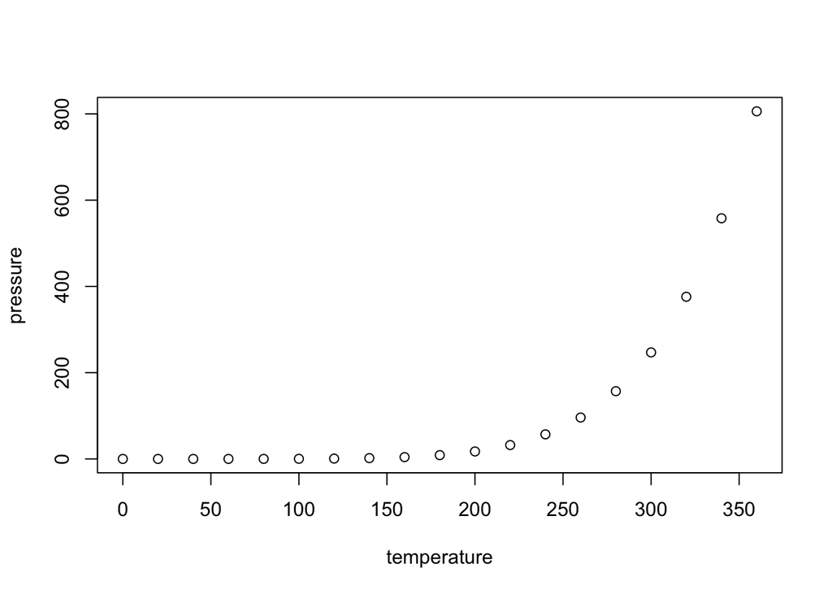

```r
summary(pressure)
plot(pressure)
```

[output not shown]

```r
# USER 2: Delete the line summary(pressure) above, then add the following 2 lines in place of it. Also add a comment with your initial so that others know you added that. Then commit to your branch.
# This is added by ???
# tail(pressure,8)
```

Then we try include=FALSE

Plot is a general function in the base library to make plots. It can make different kinds of plots, depending on the dataframe you put in.

# 3 Biggest Header (h1): What is a package?

## 3.1 Slightly Bigger Header (h2)

### 3.1.1 Somewhat Bigger Header (h3)

#### 3.1.1.1 Header line (h4, bold faced)

You can also include **in-line** R calculations like this: the average pressure is 124.337.

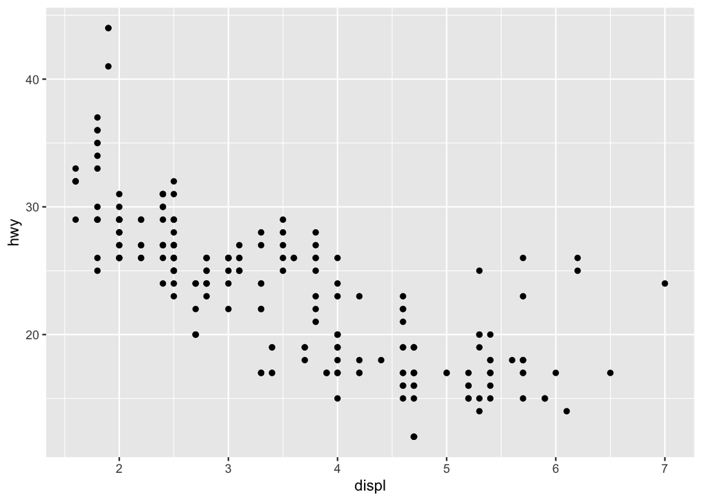

```r
loadPkg("ggplot2") # you can use library with or without double quotes. But install.packages requires double quotes.
# edit(mpg)
# ?mpg # same as help(mpg)
head(mpg)
ggplot(data=mpg)+
  geom_point(mapping = aes(x=displ, y=hwy))
```

[output not shown]

Now we can also add a color into the mix with a simple adjustment to the code

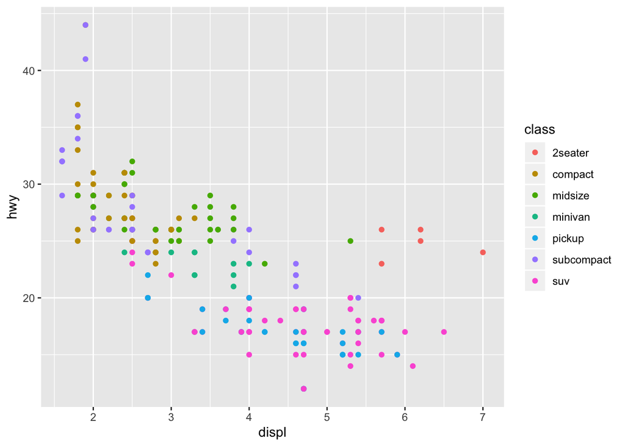

```r
ggplot(data=mpg)+
  geom_point(mapping = aes(x=displ, y=hwy, color=class))
```

So how do we get data into R: First we have to know where R is pulling our data from, we can do this by determing the location of our current working directy

```r
getwd()
```

[output not shown]

If you want to move your working directory you can use the setwd(“Insert File Location Here”)

```r
# Admit = data.frame(read.csv("LogRegAdmit.csv"))
Admit = data.frame(c(0,1,1,1,0,1,1,0,1),c(380,660,800,640,520,760,560,400,540),c(3.61,3.67,4.00,3.19,2.93,3.00, 2.98, 3.08, 3.39),c(3,3,1,4,4,2,1,2,3))
colnames(Admit) = c('admit','gre','gpa','rank')
head(Admit)
```

[output not shown]

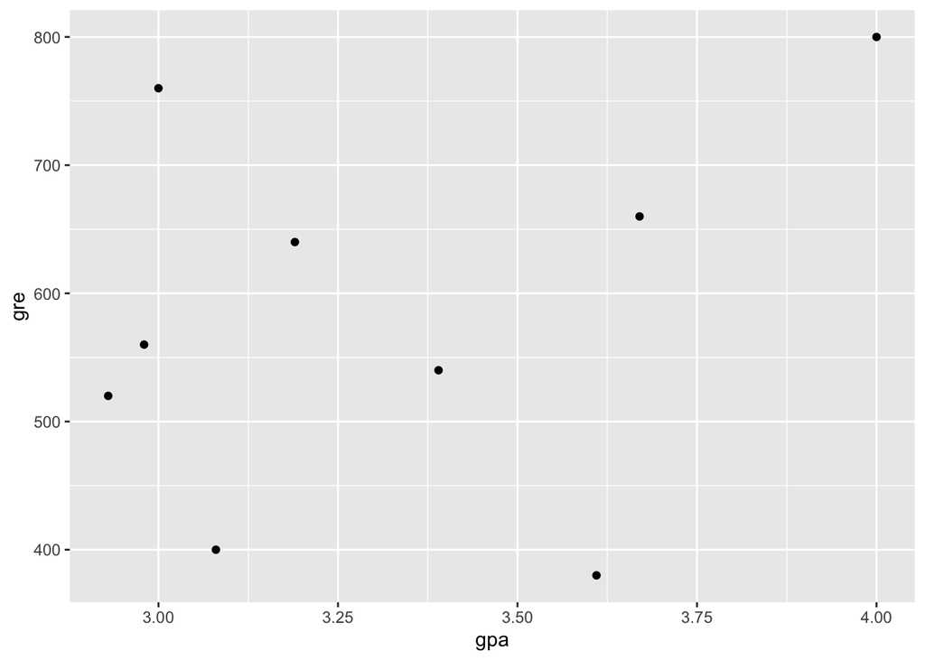

```r
# loadPkg("ggplot2")
head(Admit)
loadPkg("tidyverse")
glimpse(Admit)
ggplot(data=Admit)+
  geom_point(mapping = aes(x=gpa, y=gre))
```

[output not shown]

```r
# detach("package:ggplot2", unload = T) # consider detach packages no longer use to free up system memory
```

As you might now notice, install.packages does not work well with knitr. You will need to comment out these lines before knitting. Other functions such as “View”, “edit”, which shifts the focus to another window/tab also do not work well with knitting. You will also need to comment out those lines as well. Note that without double blank space in the previous line, is different from here, with 2 spaces at the end.  
Can you see the difference?

With or without 2 spaces at the end, if there is a blank line, then it will always be a new paragraph.